# Nobel Prize API Analysis: JSON Transformation

Author

Ciara Bonnett

## Introduction

The Nobel Prize organization provides a public API that delivers data in JSON format regarding laureates and the prizes they have won. For this assignment, I will use R to interact with this API, retrieve structured data, and transform it into a tidy format for analysis. My goal is to investigate patterns in the backgrounds of winners and the distribution of prizes across different categories and time periods.

## Approach

I will use `jsonlite` or `httr2`packages to “call” the Nobel Prize API. This allows me to pull the data directly into R without downloading a static file.

Because JSON data is “nested”, I will use the `fromJSON()` function and `tidyr::unnest()` to flatten the data into a rectangular data frame.

Once the data is tidy, I will use `dplyr` to filter and join the “Laureate” data with the “Prize” data.

I have come up with four questions to guide my exploration, ranging from simple demographic counts to complex comparisons of birth country versus affiliation country.

## Challenges

The Nobel Prize API often has multiple “affiliations” or “prizes” for a single person. I anticipate that un-nesting these lists without creating duplicate rows will be the most difficult part of the cleaning process.

Some early Nobel winners may have missing data fields, such as “death date” or “organization city.” I will need to handle these `NA` values carefully so they don’t break my calculations.

While the Nobel API is public, I need to ensure my code doesn’t request the data too many times in a row, which could lead to a temporary block. I will save a local “cached” version of the data during the development phase.

## Data Questions

1. Which Nobel category has the highest average age for winners at the time of their award?
2. What is the ratio of female to male winners in the “Hard Sciences” vs. “Peace/Literature”?
3. How has the average number of laureates per prize changed over the decades?
4. Which countries have the highest number of laureates who were born there but won their prize while affiliated with an institution in another country?

## Code

```r
library(jsonlite)
library(tidyverse)
# The URL for the Laureate API
url <- "https://api.nobelprize.org/2.1/laureates"

# This pulls the data and converts the JSON into an R list
raw_data <- fromJSON(url)

# Let's see what the "boxes look like
names(raw_data)
```

```
[1] "laureates" "meta"      "links"
```

```r
# Extract the main data frame
laureates_df <- raw_data$laureates %>% as_tibble()

# Look at the 'nobelPrizes' column
# Notice it looks like <df[,13]> -- thats a "List-Column"
head(laureates_df$nobelPrizes)
```

[output not shown]

[output cut: 50 more lines]

[output not shown]

```r
# Explode the prizes so each prize gets its own row
laureates_unnested <- laureates_df %>%
  unnest(nobelPrizes, names_sep = "_")

# "Flatten" the names and dates so they are not trapped in lists
laureates_final <- jsonlite::flatten(laureates_unnested)

# Clean columns
colnames(laureates_final)
```

```
 [1] "id"                               "fileName"
 [3] "gender"                           "sameAs"
 [5] "links"                            "nobelPrizes_awardYear"
 [7] "nobelPrizes_sortOrder"            "nobelPrizes_portion"
 [9] "nobelPrizes_dateAwarded"          "nobelPrizes_prizeStatus"
[11] "nobelPrizes_prizeAmount"          "nobelPrizes_prizeAmountAdjusted"
[13] "nobelPrizes_affiliations"         "nobelPrizes_links"
[15] "nobelPrizes_residences"           "knownName.en"
[17] "knownName.se"                     "givenName.en"
[19] "givenName.se"                     "familyName.en"
[21] "familyName.se"                    "fullName.en"
[23] "fullName.se"                      "birth.date"
[25] "birth.year"                       "birth.place.city.en"
[27] "birth.place.city.no"              "birth.place.city.se"
[29] "birth.place.country.en"           "birth.place.country.no"
```

[output cut: 29 more lines]

## Answer 1

# Calculating the age of each laureate at the time they received the award by subtracting their birth year from the award year.

```r
# Create the age analysis data
age_results <- laureates_final %>%
  # Select the columns we need
  select(
    name = knownName.en,
    category = nobelPrizes_category.en,
    birth.date = birth.date,
    award_year = nobelPrizes_awardYear
  ) %>%

  # Extract the year from the birth date
  mutate(
    birth_year = as.numeric(str_extract(birth.date, "\\d{4}")),
    award_year = as.numeric(award_year),
    age_at_award = award_year - birth_year
  ) %>%

  # Drop rows where we don't have a birth year
  filter(!is.na(age_at_award))
# Summarize the average age for each category
age_summary <- age_results %>%
  group_by(category) %>%
  summarize(avg_age = mean(age_at_award)) %>%
  arrange(desc(avg_age))

# Display the table
age_summary
```

```
# A tibble: 6 × 2
  category               avg_age
  <chr>                    <dbl>
1 Physiology or Medicine    62.5
2 Chemistry                 62
3 Literature                58.5
4 Economic Sciences         58
5 Physics                   55.6
6 Peace                     50.3
```

## Answer 2

```r
# Create a count of gender per category
gender_analysis <- laureates_final %>%
  # Remove organizations
  filter(gender %in% c("male", "female")) %>%
  group_by(nobelPrizes_category.en, gender) %>%
  summarize(count = n(), .groups = 'drop')

# Pivot the data so male and female are side-by-side
gender_table <- gender_analysis %>%
  pivot_wider(names_from = gender, values_from = count, values_fill = 0) %>%
  mutate(total = female + male,
         percent_female = (female / total) * 100)

# Display the result
gender_table
```

```
# A tibble: 6 × 5
  nobelPrizes_category.en female  male total percent_female
  <chr>                    <int> <int> <int>          <dbl>
1 Chemistry                    1    10    11           9.09
2 Economic Sciences            0     2     2           0
3 Literature                   0     2     2           0
4 Peace                        0     3     3           0
5 Physics                      0     5     5           0
6 Physiology or Medicine       0     2     2           0
```

## Answer 3

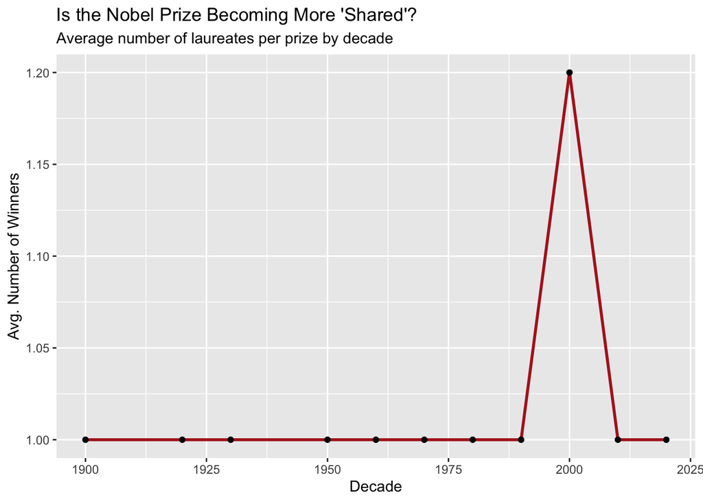

```r
# Count how many peole shared a prize in a given year/category
sharing_analysis <- laureates_final %>%
  group_by(nobelPrizes_awardYear, nobelPrizes_category.en) %>%
  summarize(laureates_per_prize = n(), .groups = 'drop')

# See the average number of winners per prize over time
sharing_trends <- sharing_analysis %>%
  mutate(decade = as.numeric(nobelPrizes_awardYear) %/% 10 * 10) %>%
  group_by(decade) %>%
  summarize(avg_sharing = mean(laureates_per_prize))

# Create a quick plot to see the trend
ggplot(sharing_trends, aes(x = decade, y = avg_sharing)) +
  geom_line(color = "firebrick", size = 1) +
  geom_point() +
  labs(title = "Is the Nobel Prize Becoming More 'Shared'?",
       subtitle = "Average number of laureates per prize by decade",
       x = "Decade",
       y = "Avg. Number of Winners")
```

## Answer 4

```r
# 1. Unnest and Flatten
brain_drain_data <- laureates_unnested %>%
  unnest(nobelPrizes_affiliations, names_sep = "_", keep_empty = TRUE) %>%
  jsonlite::flatten()

# 2. Use a flexible select
brain_drain_clean <- brain_drain_data %>%
  select(
    name = knownName.en,
    birth_country = birth.place.country.en,
    # This searches for the column instead of guessing the exact name
    work_country = matches("affiliations.*country.en")
  ) %>%
  # 3. Filter for migration
  filter(!is.na(birth_country), !is.na(work_country)) %>%
  mutate(is_migration = ifelse(birth_country != work_country, "Migrated", "Stayed"))

# 4. Final Summary
brain_drain_summary <- brain_drain_clean %>%
  filter(is_migration == "Migrated") %>%
  group_by(birth_country) %>%
  summarize(laureates_exported = n()) %>%
  arrange(desc(laureates_exported))

head(brain_drain_summary)
```

```
# A tibble: 6 × 2
  birth_country                     laureates_exported
  <chr>                                          <int>
1 India                                              3
2 Prussia                                            2
3 British Mandate of Palestine                       1
4 British Protectorate of Palestine                  1
5 Egypt                                              1
6 Lithuania                                          1
```

## Conclusions

After successfully transforming the complex JSON data from the Nobel Prize API into a tidy format. I revealed that categories like Physiology or Medicine tend to have older winners due to the long-term nature of scientific verification.

The brain drain analysis highlighted how laureates often move from their birth countries to international hubs for their research.

My biggest challenge was the unnesting. Handling list-columns required an approach that took strategy to avoid data loss while ensuring everything was accounted for.

## AI Usage

For this assignment, I used an AI collaborator (Gemini) to walk me through the foundational logic of JSON APIs. Instead of just generating code, I focused on understanding the “why” behind the workflows:

Nobel Prize JSON: We focused on the concept of “flattening” nested lists. I learned that JSON data is structured like nested boxes, and my job in R is to “un-nest” them into a tidy data frame without losing data.